# Data 607 Final Project: Movie Review Sentiment Analysis

Valerie Briot, Christophe Hunt, Armenoush Aslanian-Persico

May 2016

# Introduction and Motivation

We set out to compare 2016 New York Times movie reviews and tweets related to a given set of movies.

[figure not shown]

[figure not shown]

[figure not shown]

We envisioned a sentiment analysis comparison of the two data sources. How favorably did the New York Times review a given movie compared to the average sentiment on Twitter?

What could this information show us? How could the resulting analysis be helpful to moviegoers and the movie industry?

# Data Science Workflow

We began by identifying our project goals and scope, assessing potential data sources, and retrieving the data.

We first performed an API pull of a list of recent New York Times movie reviews.

We then performed an API pull of recent tweets. We learned that Twitter provides only a limited search history for publicly available tweets. This resulted in an adjustment of our project scope.

We then adjusted the date range of our New York Times movie list to contain only the movies with available Twitter data.

We ran a sentiment analysis on the text of the tweets and the text of the movie reviews for the given set of movies.

We created data frames for our data sources, cleaned and transformed the data, and performed analysis on the resulting datasets.

[figure not shown]

# Libraries

The following libraries were required.

```r
library(indicoio)
```

```r
library(DT)
library(ggplot2)
library(httr)
library(jsonlite)
library(knitr)
library(leaflet)
library(plotly)
library(plyr)
library(dplyr)
library(RColorBrewer)
library(RCurl)
library(rmarkdown)
library(ROAuth)
library(stringr)
library(tidyr)
library(twitteR)
library(XML)
library(scales)
```

# Sources

## Part 1. Twitter Search Setup

We registered for a Twitter API key to perform the search of public tweets related to movies.

This code chunk (`Twitter Setup`) was run first as it requires a PIN given by Twitter.

```r
library(twitteR)
library(httr)
library(ROAuth)

consumer_key <- "consumer_key"
consumer_secret <- "consumer_secret"
access_token <- "access_token"
access_secret <- "access_secret"

download.file(url='http://curl.haxx.se/ca/cacert.pem', destfile='cacert.pem')
reqURL <- 'https://api.twitter.com/oauth/request_token'
accessURL <- 'https://api.twitter.com/oauth/access_token'
authURL <- 'https://api.twitter.com/oauth/authorize'
Cred <- OAuthFactory$new(consumerKey=consumer_key,
                         consumerSecret=consumer_secret,
                         requestURL=reqURL,
                         accessURL=accessURL,
                         authURL=authURL)

Cred$handshake(cainfo = system.file('CurlSSL',
                                    'cacert.pem',
                                    package = 'RCurl'))
```

We then ran the following chunks after entering the PIN for Twitter Authorization.

```r
save(Cred, file='twitter authentication.Rdata')
load('twitter authentication.Rdata')
setup_twitter_oauth(consumer_key,
                    consumer_secret,
                    access_token,
                    access_secret)
```

## Part 2. NYT Movie Review API

We registered for a New York Times Movie API key to pull the movie review data.

We used the opening date range 2016-04-21 through 2016-05-07.

```r
#required libraries
library(jsonlite)
library(knitr)

#RESULTS 0-20 AS OF 2016-05-07
NYTREVIEWS_JSON_URL1 = paste0('http://api.nytimes.com/svc/movies/v2/reviews/search.json?opening-date=2016-04-21;2016-05-07&api-key=',YOURAPIKEYHERE, '&order=by-title', collapse = "")#url for api results 0-20
json_file1 <- fromJSON(URLencode(NYTREVIEWS_JSON_URL1))# get json
df1 <- as.data.frame(json_file1$results) #dataframe for results
#str(df1) #view structure
#colnames(df1) #view column names
df1s<-df1[,c(1:8)] #subset needed columns
#kable(df1s) #test


#RESULTS 21-40 AS OF 2016-05-07
NYTREVIEWS_JSON_URL2 = paste0('http://api.nytimes.com/svc/movies/v2/reviews/search.json?opening-date=2016-04-21;2016-05-07&api-key=', YOURAPIKEYHERE, '&offset=20&order=by-title', collapse = "") #url for api results 20-40
json_file2 <- fromJSON(NYTREVIEWS_JSON_URL2) #get json
df2 <- as.data.frame(json_file2$results) #dataframe for results
df2s<-df2[,c(1:8)] #subset needed columns

#kable(df2s) #test

#test
#NYTREVIEWS_JSON_URL3 = 'http://api.nytimes.com/svc/movies/v2/reviews/search.json?opening-date=2016-04-21;2016-05-07&api-key=YOURAPIKEYHERE&offset=40'
#json_file3 <- fromJSON(NYTREVIEWS_JSON_URL3) #get json
#df3 <- as.data.frame(json_file3$results) #dataframe for results
#df3s<-df3[,c(1:8)] #subset needed columns
#kable(df3s)

#ALL RESULTS 0-40 COMBINED
df<- rbind(df1s,df2s) #combine all results
#knitr::kable(df, row.names =TRUE) #test

#ADD URL COLUMN TO RESULTS
url1 <- json_file1$results$link #collect links part 1
url1<-url1[,c(1:2)] #subset links
url2 <- json_file2$results$link #collect links part 2
url2<-url2[,c(1:2)] #subset links
#str(url1) #test
urls<- rbind(url1,url2) #combine all results for links
#knitr::kable(urls, row.names = TRUE) #test
combo<-cbind(df,urls) #combine reviews and links
combo<-combo[,c(1:3,7,8,10)] #subset needed columns
combo<-combo[,c(1,5,4,6,2,3)] #reorder needed columns
kable(combo, row.names = TRUE) #display with row numbers
write.table(combo, "nytmovies.csv") #export to CSV
```

The resulting CSV is available here:

[List of New York Times Movie Reviews With URLs](https://raw.githubusercontent.com/spsstudent15/Data607FinalProject/master/nytmovies.csv)

## Part 3. NYT Sentiment Analysis

For each URL pointing to a movie review, we then scraped the text of the review. Only the actual text of the review was considered. This was indicated by the class = ‘story-body-text story-content’ under the paragraph tag “< p >”. In addition, we retrieved the genre of the movie listed in the individual review. The genres are indicated by the following tag <span itemprop=‘genre’ class=’genre>. For movies categorized as more than one genre, we retrieved only the first genre tag.

We then ran the review text through sentiment analysis with indico, resulting in a 0-1 score, with 1 being most positive.

For reproducibility of results, we read the review list and URLs from Github.

```r
# Retrieve list of movie from Github
movie_list_url <- getURL("https://raw.githubusercontent.com/spsstudent15/Data607FinalProject/master/nytmovies2.csv")
movie_list <- read.csv(textConnection(movie_list_url), header = TRUE, sep = ",")

movie_list[1:5,]
str(movie_list)


# initialize resulting data frame
movie_score_nyt <- data.frame()

# initialize variables:

# INDICO API Key
my_indicoio_API_Key <-"2cf9508e4628b67c9b69ae7d1059efda"

# Set Up xpath to retrieve review and genre
xpath_review <- "//p[@class = 'story-body-text story-content']"
xpath_genre <- "(//span[@itemprop='genre'][@class = 'genre'])[1]" # will only retrieve first one

agent <- c(R.version$version.string, ",", R.version$platform)

# Loop through movie list, retrieve review for each movie review url
loop_counter <- nrow(movie_list)

for (i in 1:loop_counter){

  #Set RCurl pars
  curl <- getCurlHandle()
  curlSetOpt(cookiejar="cookies.txt",  useragent = agent, followlocation = TRUE, curl=curl)

  movie_url <-  movie_list$url[i]

  # Get Review corresponding the url
  my_movie <- getURL(as.character(movie_url), curl = curl, verbose = FALSE)

  content_review = htmlTreeParse(my_movie, asText=TRUE, useInternalNodes = TRUE, encoding = 'UTF-8')

  plain_text <- xpathSApply(xmlRoot(content_review), xpath_review, xmlValue)
  review_df <- as.data.frame(as.character(paste(plain_text, collapse = " ")))

  colnames(review_df) <- "review"
  review_df$movie <- movie_list$movie[i]

  review_df$Sentiment_Score_nyt <- unlist(sentiment(as.character(review_df$review), api_key = my_indicoio_API_Key))

  genre <- xpathSApply(xmlRoot(content_review), xpath_genre, xmlValue)
  review_df$genre <-genre

  movie_score <- rbind(movie_score, review_df)
}

movie_score_nyt <- inner_join(movie_list, movie_score, by = "movie")


write.csv(movie_score_nyt, file = "movie_df.csv", sep = ",")
```

The resulting CSV is available here:

[NYT Movie Reviews With Full Text and Sentiment Score](https://raw.githubusercontent.com/spsstudent15/Data607FinalProject/master/movie_score_nyt.csv)

## Part 4. Twitter Sentiment Analysis

Once we established the list of available New York Times movie reviews, we ran the Twitter search using the movie title as a search term. To get better Twitter search results for one-word movies, we added the word “movie” to our search term.

This chunk retrieved the Twitter search results for a term. `searchTwitter` has some other settings that could probably improve results.

We used the indico package to perform sentiment analysis, resulting in a score of 0-1 for each tweet, 1 being extremely positive.

We decided to use unique tweets only, therefore eliminating any retweet data.

For the benefit of our analysis, we filtered the Twitter search results to pull only the tweets which were coded with geographical location.

We chose the following cities at random and pulled tweets for only these cities.

```r
#'r paste(str_trim(locations$City), collapse = ", ")`.
library(knitr)
library(RCurl)
citiesurl <- getURL("https://raw.githubusercontent.com/spsstudent15/Data607FinalProject/master/locations.csv")

citiesxy<- data.frame(read.csv(text=citiesurl))

kable(citiesxy)
```

| City | Lat | Long |
| --- | --- | --- |
| Boston | 42.35997 | -71.06009 |
| New York City | 40.72541 | -73.99292 |
| Chicago | 41.87621 | -87.62833 |
| Lincoln | 40.82550 | -96.67557 |
| New Orleans | 29.94048 | -90.05229 |
| Los Angeles | 34.05223 | -118.24368 |
| Seattle | 47.61000 | -122.33000 |
| Houston | 29.71892 | -95.33916 |
| St. Louis | 38.64699 | -90.22497 |
| Denver | 39.73915 | -104.98470 |

We mapped these cities with Leaflet.

```r
data.url <- file(paste(url,"locations.csv", sep = ""), open="r" )
locations <- read.csv(data.url, sep=",", header=TRUE, stringsAsFactors = FALSE)
close(data.url)
```

```r
library(leaflet)
leaflet(locations) %>%
  addProviderTiles("Stamen.Toner") %>%
  addMarkers(lng = ~Long, lat = ~Lat, popup = paste(as.character(str_trim(locations$City))))
```

[interactive chart not shown]

Using the full list of reviews, we cleaned up character and encoding issues to be able to search Twitter by movie name.

We retrieved tweets based on our date range and geographical locations, then used Indico to generate a sentiment score for each individual tweet.

```r
library(indicoio)

rm_special <-function(x) iconv(x, "UTF-8", "UTF-8",sub='')

search_term <- function(term){
                  require(magrittr)
                  search_term <- gsub(" ", "+", term) %>%
                                 paste("+movie", sep = "")
                  return(search_term)
                }


df <- NULL
for (i in movies$display_titles){
  SearchTerm <- search_term(i)
  for (j in seq(1:length(locations$City))){
      list <- suppressWarnings(searchTwitter(SearchTerm,
                                             since = format(Sys.Date()-1,format="%Y-%m-%d"),
                                             until = format(Sys.Date(),format="%Y-%m-%d"), n = 5000,
                                             geocode = paste(locations$Lat[j], ",", locations$Long[j], ",30mi", sep = "" )
                                             ))
          if (length(list) == 0){
            NULL
          } else {
          tweetdf <- twListToDF(list)
          tweetdf <- as.data.frame(unique(tweetdf$text))
          colnames(tweetdf) <- c("tweet")
          tweetdf$city <- locations$City[j]
          tweetdf$movie <- as.character(i)
          tweetdf$day <- format(Sys.Date() ,format="%m.%d.%Y")
          df <- rbind(df,tweetdf)
          }
         }
       }

df$Sentiment_Score <- unlist(sentiment(as.character(rm_special(df$tweet)),  api_key = indico_api_key))
write.csv(df, file = paste("Tweets for ", as.character(format(Sys.Date(), format="%m.%d.%Y")), ".csv", sep = ""))
```

The resulting Twitter CSVs for individual days are available here:

[Tweets for 20160503](https://raw.githubusercontent.com/spsstudent15/Data607FinalProject/master/Tweets%20for%2005.03.2016.csv)

[Tweets for 20160504](https://raw.githubusercontent.com/spsstudent15/Data607FinalProject/master/Tweets%20for%2005.04.2016.csv)

[Tweets for 20160505](https://raw.githubusercontent.com/spsstudent15/Data607FinalProject/master/Tweets%20for%2005.05.2016.csv)

[Tweets for 20160506](https://raw.githubusercontent.com/spsstudent15/Data607FinalProject/master/Tweets%20for%2005.06.2016.csv)

[Tweets for 20160507](https://raw.githubusercontent.com/spsstudent15/Data607FinalProject/master/Tweets%20for%2005.07.2016.csv)

[Tweets for 20160508](https://raw.githubusercontent.com/spsstudent15/Data607FinalProject/master/Tweets%20for%2005.08.2016.csv)

[Tweets for 20160509](https://raw.githubusercontent.com/spsstudent15/Data607FinalProject/master/Tweets%20for%2005.09.2016.csv)

[Complete Dataset of All Tweets With Sentiment Score](https://raw.githubusercontent.com/spsstudent15/Data607FinalProject/master/tweets503to509.csv)

# Transformation and Analysis

## New York Times

### New York Times Sentiment Analysis Litmus Test

We performed a sentiment analysis litmus test for New York Times reviews. The Times does not provide “stars” to rate their movie reviews but favorable reviews will be tagged with a “Critics’ Pick.” As a test for the sentiment analysis accuracy, we analyzed the results as follows:

We considered a “good” score any score >= 0.75 and expected the movie to be tagged with “Critics’s Pick” (value = 1).

```r
url <- "https://raw.githubusercontent.com/spsstudent15/Data607FinalProject/master/"
data.url <- file(paste(url,"movie_score_nyt.csv", sep = ""), open="r" )
movie_score_nyt <- read.csv(data.url, sep=",", header=TRUE, stringsAsFactors = FALSE)

nyt_false_positive <- movie_score_nyt %>% filter(Sentiment_Score_nyt < 0.75 & critics_pick == 1) %>%
                    select(movie, mpaa_rating, genre, Sentiment_Score_nyt, critics_pick)

nyt_false_negative <- movie_score_nyt %>% filter(Sentiment_Score_nyt >= 0.75 & critics_pick == 0) %>%
                     select(movie, mpaa_rating, genre, Sentiment_Score_nyt, critics_pick)

nyt_true_negative <- movie_score_nyt %>% filter(Sentiment_Score_nyt < 0.75 & critics_pick == 0) %>%
                     select(movie, mpaa_rating, genre, Sentiment_Score_nyt, critics_pick)

nyt_true_positive <- movie_score_nyt %>% filter(Sentiment_Score_nyt >= 0.75 & critics_pick == 1) %>%
                      select(movie, mpaa_rating, genre, Sentiment_Score_nyt, critics_pick)

close(data.url)
```

Percentage of False Positive: 5%  
Percentage of False Negative: 35%  
Percentage of True Positive: 15%  
Percentage of True Negative: 45%

### New York Times Sentiment Summary

For the New York Times data, we created a sentiment score summary table without the full review text for easier analysis.

```r
url <- "https://raw.githubusercontent.com/spsstudent15/Data607FinalProject/master/"

data.url <- file(paste(url,"movie_score_nyt.csv", sep = ""), open="r" )
reviewscore <- read.csv(data.url, sep=",", header=TRUE, stringsAsFactors = FALSE)

reviewscore<-reviewscore[,c(2:5,7:8,10:11)] #subset needed columns
#kable(reviewscore)
close(data.url)
```

```r
nytsent<-getURL("https://raw.githubusercontent.com/spsstudent15/Data607FinalProject/master/sentimentsummarynyt.csv")

df<- data.frame(read.csv(text=nytsent))

datanyt<-df[,c(3:4,7:9)]
datanyt$Sentiment_Score_nyt=round(datanyt$Sentiment_Score_nyt,3) #round decimals to 3 places

datatable(datanyt, options = list( pageLength = 5, lengthMenu = c(5, 10, 40)), rownames= TRUE)
```

|  | movie | opening_date | critics_pick | Sentiment_Score_nyt | genre |
| --- | --- | --- | --- | --- | --- |
| 1 | A Beautiful Planet | 4/29/2016 | 0 | 1 | Documentary |
| 2 | A Bigger Splash | 5/4/2016 | 1 | 0.994 | Crime |
| 3 | A Hologram for the King | 4/22/2016 | 1 | 0.398 | Drama |
| 4 | Baaghi | 4/29/2016 | 0 | 0.069 | Action |
| 5 | Beautiful Something | 5/6/2016 | 0 | 0.983 | Drama |
| 6 | Being Charlie | 5/6/2016 | 0 | 0.041 | Drama |
| 7 | Bourek | 4/29/2016 | 0 | 0.352 | Comedy |
| 8 | Captain America: Civil War | 5/6/2016 | 0 | 0.974 | Action |
| 9 | Compadres | 4/22/2016 | 0 | 0.158 | Action |
| 10 | Dark Horse | 5/6/2016 | 1 | 0.847 | Documentary |

[output cut: 30 more lines]

```r
write.csv(reviewscore, file = "sentimentsummarynyt.csv", sep = ",")
```

The resulting CSV is available here:

[NYT Sentiment Summary](https://raw.githubusercontent.com/spsstudent15/Data607FinalProject/master/sentimentsummarynyt.csv)

## Twitter

### Twitter Daily Breakdown

We analyzed each day’s worth of tweets separately to identify outliers and possible trends. The complete daily analysis is available here.

[Analysis of Movie Tweets By Day](http://rpubs.com/aapsps/179750)

### Twitter Combined Data

We combined all seven days of tweets into one dataframe of 5,445 records. This served as our primary Twitter dataset.

### Twitter Sentiment Summary

We looked at the average Twitter Sentiment by movie.

```r
tweets1 <- getURL("https://raw.githubusercontent.com/spsstudent15/Data607FinalProject/master/tweets503to509.csv")

tweets1<- data.frame(read.csv(text=tweets1))
```

```r
tweets1$city[tweets1$city == 'los Angeles'] <- 'Los Angeles'
tweets1$movie <- encodeString(as.character(tweets1$movie))
tweets1$movie[tweets1$movie == 'Mother<U+0092>s Day'] <- "Mother's Day"
tweets1$movie[tweets1$movie == "L<U+0092>Attesa (The Wait)"] <- "L'Attesa (The Wait)"
```

```r
moviesum1<- ddply(tweets1, .(movie), summarize,  Sentiment_Score=mean(Sentiment_Score), Count_of_Tweets=length(tweet)) #summarize by movie

moviesum1$movie<-as.character(moviesum1$movie) #convert levels to character
moviesum1<- arrange(moviesum1, movie) #sort alphabetically by movie name
#moviesum1$num<-seq.int(nrow(moviesum1)) # add counter row

names(moviesum1)<-c("Movie","Sentiment_Score","Count_of_Tweets")
```

```r
twittersent<-getURL("https://raw.githubusercontent.com/spsstudent15/Data607FinalProject/master/sentimentsummarytwitter.csv")

df<- data.frame(read.csv(text=twittersent))

datatw<-df[,c(2:4)]
datatw$Sentiment_Score=round(datatw$Sentiment_Score,3) #round decimals to 3 places

datatable(datatw, options = list(columnDefs = list(list(className = 'dt-center', targets = 3)), pageLength = 5, lengthMenu = c(5, 10, 40)), rownames= TRUE) #create data table for display
```

|  | movie | Sentiment_Score | Count_of_Tweets |
| --- | --- | --- | --- |
| 1 | A Beautiful Planet | 0.715 | 93 |
| 2 | A Bigger Splash | 0.532 | 51 |
| 3 | A Hologram for the King | 0.779 | 4 |
| 4 | Baaghi | 0.594 | 31 |
| 5 | Being Charlie | 0.634 | 17 |
| 6 | Captain America: Civil War | 0.784 | 1508 |
| 7 | Dark Horse | 0.661 | 31 |
| 8 | Dough | 0.566 | 31 |
| 9 | Elstree 1976 | 0.757 | 14 |
| 10 | Elvis &amp; Nixon | 0.607 | 3 |

[output cut: 24 more lines]

```r
datatable(datatw, options = list(pageLength = 5, lengthMenu = c(5, 10, 40)), rownames= TRUE)
```

|  | movie | Sentiment_Score | Count_of_Tweets |
| --- | --- | --- | --- |
| 1 | A Beautiful Planet | 0.715 | 93 |
| 2 | A Bigger Splash | 0.532 | 51 |
| 3 | A Hologram for the King | 0.779 | 4 |
| 4 | Baaghi | 0.594 | 31 |
| 5 | Being Charlie | 0.634 | 17 |
| 6 | Captain America: Civil War | 0.784 | 1508 |
| 7 | Dark Horse | 0.661 | 31 |
| 8 | Dough | 0.566 | 31 |
| 9 | Elstree 1976 | 0.757 | 14 |
| 10 | Elvis &amp; Nixon | 0.607 | 3 |

[output cut: 24 more lines]

```r
write.csv(moviesum1, file = "sentimentsummarytwitter.csv", sep = ",")
```

The resulting CSV is available here:

[Twitter Sentiment Summary](https://raw.githubusercontent.com/spsstudent15/Data607FinalProject/master/sentimentsummarytwitter.csv)

### Twitter City Score

We looked at the average Twitter sentiment by city.

```r
citysum1<- ddply(tweets1, .(city), summarize,  Sentiment_Score=mean(Sentiment_Score), Count_of_Tweets=length(tweet)) #summarize by city
kable(citysum1, rownames = TRUE)
```

| city | Sentiment_Score | Count_of_Tweets |
| --- | --- | --- |
| Boston | 0.6685495 | 207 |
| Chicago | 0.6869049 | 526 |
| Denver | 0.7415370 | 165 |
| Houston | 0.7692286 | 284 |
| Lincoln | 0.7168697 | 12 |
| Los Angeles | 0.6937290 | 1724 |
| New Orleans | 0.6528819 | 99 |
| New York City | 0.7133538 | 2076 |
| Seattle | 0.7025967 | 218 |
| St. Louis | 0.8095269 | 134 |

## Comparison

```r
datanyt<- datanyt %>% left_join(datatw, by = "movie")

datacombo<- datanyt[,c(1,4,6,3,7,2,5)]

names(datacombo)<-c("Movie","NYT_Sentiment","Twitter_Sentiment","NYT_CriticsPick","Count_of_Tweets","Opening_Date","Genre")

#kable(datacombo)

datatable(datacombo, options = list( pageLength = 40, lengthMenu = c(5, 10, 40)), rownames= TRUE)
```

|  | Movie | NYT_Sentiment | Twitter_Sentiment | NYT_CriticsPick | Count_of_Tweets | Opening_Date | Genre |
| --- | --- | --- | --- | --- | --- | --- | --- |
| 1 | A Beautiful Planet | 1 | 0.715 | 0 | 93 | 4/29/2016 | Documentary |
| 2 | A Bigger Splash | 0.994 | 0.532 | 1 | 51 | 5/4/2016 | Crime |
| 3 | A Hologram for the King | 0.398 | 0.779 | 1 | 4 | 4/22/2016 | Drama |
| 4 | Baaghi | 0.069 | 0.594 | 0 | 31 | 4/29/2016 | Action |
| 5 | Beautiful Something | 0.983 |  | 0 |  | 5/6/2016 | Drama |
| 6 | Being Charlie | 0.041 | 0.634 | 0 | 17 | 5/6/2016 | Drama |
| 7 | Bourek | 0.352 |  | 0 |  | 4/29/2016 | Comedy |
| 8 | Captain America: Civil War | 0.974 | 0.784 | 0 | 1508 | 5/6/2016 | Action |
| 9 | Compadres | 0.158 |  | 0 |  | 4/22/2016 | Action |
| 10 | Dark Horse | 0.847 | 0.661 | 1 | 31 | 5/6/2016 | Documentary |

[output cut: 30 more lines]

```r
write.csv(datacombo, file = "sentimentsummarycombo.csv", sep = ",")
```

The resulting CSV is available here:

[Comparison Summary](https://raw.githubusercontent.com/spsstudent15/Data607FinalProject/master/sentimentsummarycombo.csv)

# Visualization

## NYT vs. Twitter

We compared New York Times review sentiment score and Twitter average sentiment score for the top 10 movies by tweet count

```r
library(plotly)

top_movies <- ddply(tweets1, ~movie, summarize, tweet_count = length(tweet))
top_movies <- top_movies[order(-top_movies$tweet_count),]
n <- 10
top_movies <- head(top_movies$movie, n = n)
data.url <- file(paste(url,"movie_score.csv", sep = ""), open="r" )
movies_score_NYT <- read.csv(data.url, sep=",", header=TRUE, stringsAsFactors = FALSE)
movies_score_NYT$movie[movies_score_NYT$X == 22] <- "Mother's Day"
movies_score_NYT_subset <- subset(movies_score_NYT, movies_score_NYT$movie %in% top_movies)

a <- list()
for (i in seq_len(nrow(movies_score_NYT_subset ))) {
  m <- movies_score_NYT_subset [i, ]
  a[[i]] <- list(
  x = movies_score_NYT_subset$movie[i],
  y = movies_score_NYT_subset$Sentiment_score[i],
  text = paste("NYT Score: <br>", signif(movies_score_NYT_subset$Sentiment_score[i],5)),
  xref = "x", yref = "y", showarrow = TRUE,  arrowhead = 7,  ax = 10,  ay = -20
  )
}

m = list( l = 50,  r = 50,  b = 150,  t = 100,  pad = 5)

xlabel <- list(title = "Movie")
ylabel <- list(title = "Setiment Score")

tweets1_subset <- subset(tweets1, tweets1$movie %in% top_movies) %>%
                  arrange(movie)

plot_ly(tweets1_subset,
        y = Sentiment_Score,
        color = movie,
        type = "box",
        boxpoints = "all", jitter = 0.3) %>%
  layout(title = sprintf("Box Plot of Movie Tweets for Top %s Movies", n),
         xaxis = xlabel,
         yaxis = ylabel,
         annotations = a,
         autosize = F, width = 1000, height = 800, margin = m)
```

[interactive chart not shown]

# Twitter Sentiment Score Confidence Interval

The below graphs display the confidence intervals for each movie based on their twitter sentiment analysis scores. We can see that for 9 of the 10 movies the New York Times sentiment score falls outside of the range of confidence interval for each movie. Since we are 95% confident that the true mean of twitter sentiment is contained in this interval we can conclude that twitter sentiment scores are not similar to sentiment scores of the New York Times review.

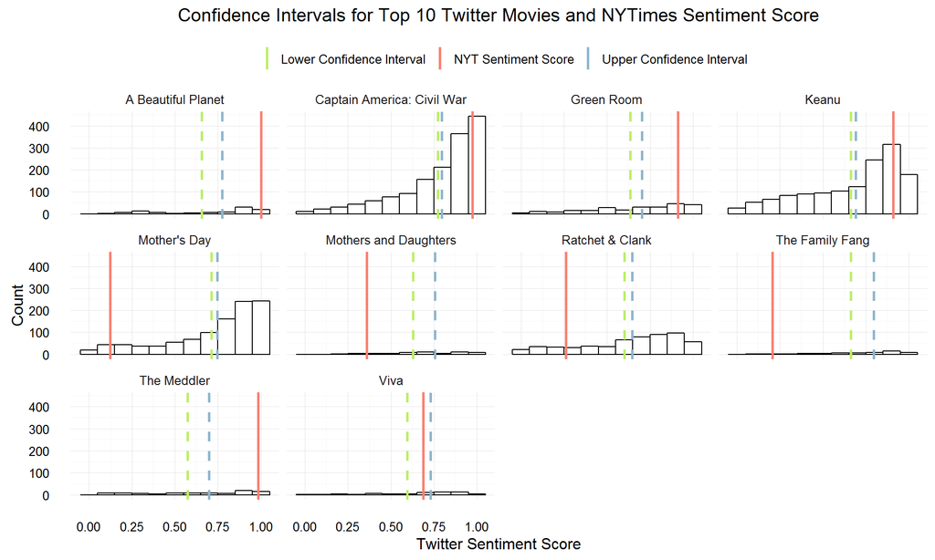

```r
tweets <- merge(tweets1, movies_score_NYT_subset[2:4]) %>%
          rename(Twitter_score = Sentiment_Score, NYT_score = Sentiment_score) %>%
          select(movie, Twitter_score, NYT_score)

tweets_confidence <- NULL
for (i in unique(tweets$movie)){
  conf <- t.test(tweets$Twitter_score[tweets$movie == i], conf.level = .95)
  results <- NULL
  results$movie <- i
  results$lower_conf <- conf$conf.int[1]
  results$upper_conf <- conf$conf.int[2]
  tweets_confidence <- rbind(tweets_confidence, as.data.frame(results))
}

tweets <- merge(tweets, tweets_confidence)

ggplot(tweets, aes(x=Twitter_score)) +
      geom_histogram(binwidth=.1, colour="black", fill="white") +
      theme_minimal() +
      theme(legend.position="top") +
      facet_wrap(~movie) +
      xlab("Twitter Sentiment Score") +
      ylab("Count") +
      ggtitle("Confidence Intervals for Top 10 Twitter Movies and NYTimes Sentiment Score") +
      geom_vline(data=unique(tweets[c("movie","NYT_score")]),
                 aes(xintercept = NYT_score, color="NYT Sentiment Score"), linetype= 1, size=1) +
      geom_vline(data = tweets[c("movie", "lower_conf")],
                 aes(xintercept = lower_conf , color = "Lower Confidence Interval"), linetype="dashed", size=1) +
      geom_vline(data = tweets[c("movie", "upper_conf")],
                 aes(xintercept = upper_conf , color = "Upper Confidence Interval"), linetype="dashed", size=1) +
      scale_colour_manual(name="", values=c("NYT Sentiment Score" ="salmon",
                                                      "Lower Confidence Interval" = "darkolivegreen2",
                                                      "Upper Confidence Interval" = "lightskyblue3"))
```

## Twitter Scores

We looked at average Twitter sentiment score by movie and by city.

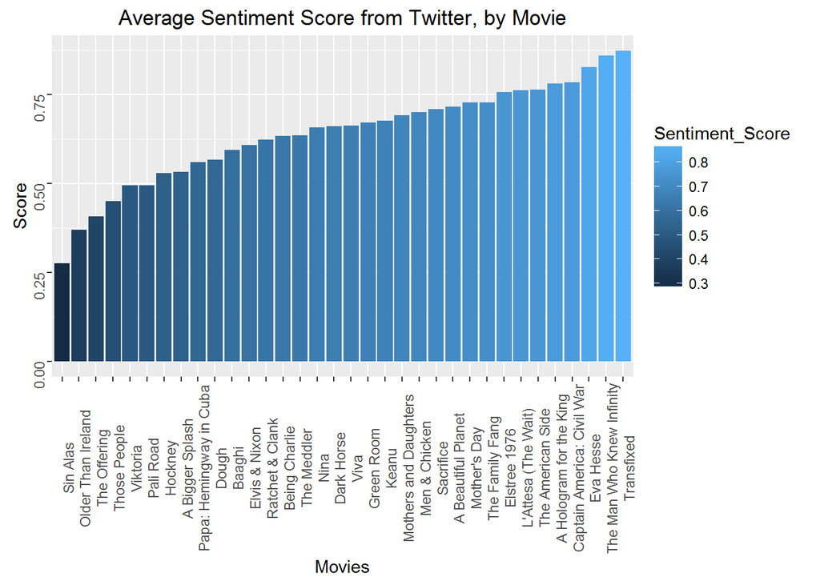

```r
ggplot(
  moviesum1, aes(x = reorder(Movie,Sentiment_Score), y = Sentiment_Score, fill=Sentiment_Score)) +
  geom_bar(stat="identity") +
  ggtitle("Average Sentiment Score from Twitter, by Movie")+
  theme(axis.text=element_text(angle=90))+
  labs(x="Movies",y="Score")
```

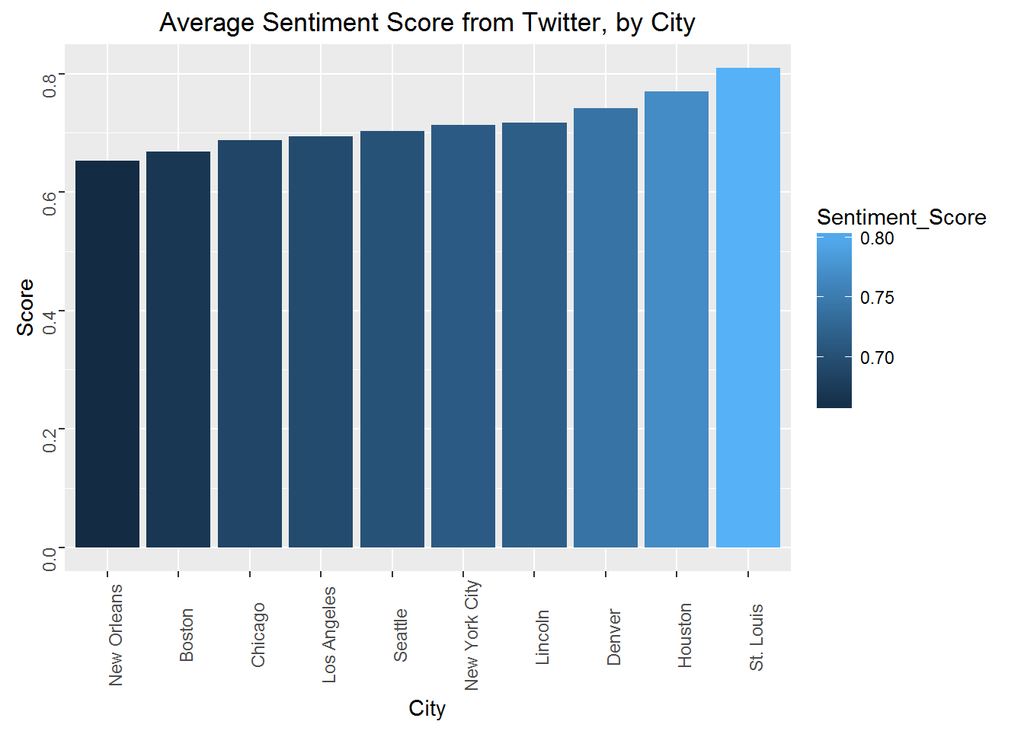

```r
ggplot(
  citysum1, aes(x = reorder(city,Sentiment_Score), y = Sentiment_Score, fill=Sentiment_Score)) +
  geom_bar(stat="identity") +
  ggtitle("Average Sentiment Score from Twitter, by City")+
  theme(axis.text=element_text(angle=90))+
  labs(x="City",y="Score")
```

We looked at average Twitter sentiment score by movie for the top 10 movies. Larger circles indicate more positive sentiment. Different colors indicate different movies.

```r
library(RColorBrewer)

mapped_tweets <- merge(tweets1, locations, all.x = TRUE, by.y = "City", by.x = "city")  %>%
                group_by(movie, city, Long, Lat) %>%
                summarise(avg_twitter_score = mean(Sentiment_Score)) %>%
                merge(movies_score_NYT[,c("movie", "Sentiment_score")], all.x = TRUE, by = "movie") %>%
                rename(NYT_sentiment_score = Sentiment_score)


mapped_tweets_top <- subset(mapped_tweets, mapped_tweets$movie %in% top_movies)

factpal <- colorFactor(brewer.pal(10, "Spectral"), mapped_tweets_top$movie)

leaflet(mapped_tweets_top) %>%
  addProviderTiles("Stamen.Toner") %>%
  addCircles(lng = ~jitter(Long, factor = 20), lat = ~jitter(Lat, factor = 20), weight = 2,
    radius = ~avg_twitter_score*100000,
    popup =paste("<font color=", factpal(mapped_tweets_top$movie), ">" ,
                 "Movie:", as.character(mapped_tweets_top$movie), "<br>",
                 "Avg Twitter Sentiment Score:", as.character(signif(mapped_tweets_top$avg_twitter_score,3)),"<br>",
                 "NYT Sentiment Score:", as.character(signif(mapped_tweets_top$NYT_sentiment_score,3)),
                 "</font>"),
    color = ~factpal(mapped_tweets_top$movie),
    fillOpacity = 0.4)
```

[interactive chart not shown]

# New Features

## Twitter API / OAUTH

We utilized the Twitter API to develop our collection of tweets. Using the `twitteR` package we were able to pull tweets for locations by setting the geocode location and radius. OAuth was necessary because the `twitteR` uses the Developer API to search tweets based on our settings, it also required interaction by allowing the application access by putting in a key given by Twitter.

## Sentiment analysis machines

We tested a number of different sentiment analysis machines.

We started out trying to using the bag of words method to count positive and negative words within the tweet to get the positivity score. The problem with this method was that many of the words we had did not show up in tweets and the context of the tweet was typically misclassified.

We realized that we needed to get some help to get a more accurate sentiment analysis. We looked into several APIs such as IBM’s [AlchemyAPI](http://www.alchemyapi.com/api/sentiment-analysis). We ended up using Indico since it offered a free tier and they had developed an easy to use `R` package.

## Indico package

We used the Indico Sentiment Analysis API to analyze our text to return the positity on a scale from 0-1. We tested out several obviously bad and positive tweets and the response was very accurate.

> Indico Benchmark: The API performs with 93% accuracy on the IMDB dataset (state of the art).

## Leaflet pakcage

The Leaflet package was simple to use with our given list of locations with latitude and longitude. One drawback is the lack of a built-in zoom reset button. The popup option is a clean way to allow for label display without clutter.

## Collaborating on Slack

We found Slack easy to use with a pleasant user interface and file sharing options. Slack may be more useful for larger groups. For our three-person group, we found that email was mostly manageable. Since we were already checking in on email, RPubs, and Github, Slack seemed like one more thing to check.

## Collaborating on Github

This was our first experience contributing to a repository using GitHub. It made sharing the code and version control of each change much easier than previous attempts.

# Challenges

**Movie titles with common words**

We encountered some issues with movies having one word titles that pulled lots of unrelated tweets. Our solution was to append `movies` to the search to try to narrow down results to just movies. One other issue is that a movie `Mother's Day` came out right before the actual Mother’s Day holiday. Many people appeared to go to the movies on Mother’s Day to celebrate but the actual movie they went to see may have been another one of the films. There are many nuances involved in pulling the tweets.

**Special characters and encoding**

Movies with accents, such as foreign movies, and movies with apostrophes in the titles caused encoding issues which had to be resolved with character substitution. Several movies would have been unintentionally omitted from the analysis if we had not resolved these characters.

**Indico limitations**

Indico’s free service allows 10,000 pulls. Each tweet is counted as one pull. For a project with a contained scope, this may be feasible. However, for long-term research studies, a paid account would be needed.

**New York Times API data**

The syntax documentation for the NYT API was easy to follow. However, the pulls seemed to omit some results. The API gave 20 results per pull, so the use of offset=20, offset=40 was required to retrieve subsequent reqsults. Despite the offset function, it was necessary to combine two weeks of pulls and eliminate duplicate records to get the full dataset for our desired date range.

# Insights and Conclusion

**Twitter Data Reliability**

Twitter has a limitation on interpretability, it is useful as a proof of concept but cannot be the sole source of information. Many tweets were commerical advertisements and had unhelpful links. Twitter is a useful tool to explore but I would not build a data product exclusively with it.

**Comparing NYT and Twitter Scores**

The Twitter data captured only 34 of our 40 New York Times reviewed movies. More obscure or independent movies, or movies with limited releases, were less likely to have mentions on Twitter. The New York Times does more in-depth cultural and artistic analysis than Twitter.

**Interpretation of results**